# R-INLA Tutorial

GEOMED 2019 Conference - August 27th, 2019

Marta Blangiardo - Imperial College

Michela Cameletti - University of Bergamo

## 1. Hierarchical model with lip cancer data

We consider data about *Lip Cancer in Scotland*. It refers to 56 counties and to the following variables:

- `id`: county id
- `O`: observed number of cases of lip cancer
- `E`: expected number of cases (adjusted by age and sex)
- `X`: exposure variable (percentage of population working in an outdoor environment, i.e. exposed to sun)

```r
library(INLA)
load("LipCancerData.RData")
head(LipCancerData)
```

```
##   id  O   E  X
## 1  1  9 1.4 16
## 2  2 39 8.7 16
## 3  3 11 3.0 10
## 4  4  9 2.5 24
## 5  5 15 4.3 10
## 6  6  8 2.4 24
```

```r
dim(LipCancerData)
```

```
## [1] 56  4
```

### 1.1 Poisson-logNormal model

We implement the following Poisson regression model:
$$O_i\sim \mbox{Poisson}(\phi_i E_i)$$
where $\phi_i$ is the relative risk.

The linear predictor is given by
$$\eta_i=\log(\phi_i)=b_0 + v_{i} + b_1 x_i$$

An **exchangeable prior** is specified on the random effect: $v_{0i}\sim\mbox{Normal}(0, 1/\tau_{v0})$, with $\tau_{v0}$ being an hyperparameter. It is internally represented as $\log\tau_{v0}$ with default prior given by $\mbox{logGamma}\sim(1, 0.00005)$ (see [linkiid](http://www.math.ntnu.no/inla/r-inla.org/doc/latent/indep.pdf)).

## 3. Run INLA

```r
formula = O ~ 1 + X + f(id,model="iid") #default prior for log tau_v: logGamma(1,5e-05)

lipcancer.poisson = inla(formula,family="poisson",
                           data=LipCancerData, offset=log(E))

summary(lipcancer.poisson)
```

```
##
## Call:
##    c("inla(formula = formula, family = \"poisson\", data = LipCancerData, ", " offset =
##    log(E))")
## Time used:
##     Pre = 1.65, Running = 0.182, Post = 0.105, Total = 1.94
## Fixed effects:
##               mean    sd 0.025quant 0.5quant 0.975quant   mode kld
## (Intercept) -0.489 0.157     -0.804   -0.488     -0.185 -0.484   0
## X            0.068 0.014      0.041    0.068      0.096  0.068   0
##
## Random effects:
##   Name     Model
##     id IID model
##
## Model hyperparameters:
##                  mean    sd 0.025quant 0.5quant 0.975quant mode
## Precision for id 3.09 0.901       1.69     2.96       5.20 2.73
##
## Expected number of effective parameters(stdev): 39.13(2.93)
## Number of equivalent replicates : 1.43
##
## Marginal log-Likelihood:  -190.24
```

## 3. Change the hyperparameter prior

Instead of the default $\mbox{logGamma}\sim(1, 0.00005)$ prior for $\log\tau_{v0}$, we want to specify a $\mbox{logGamma}\sim(1, 0.00001)$:

```r
formula = O ~ 1 + X +
                f(id,model="iid",
                  hyper=list(prec=
                               list(prior="loggamma",param=c(1,0.00001))))

lipcancer.poisson2 = inla(formula,family="poisson",
                           data=LipCancerData, offset=log(E),
                            control.compute=list(config = TRUE, #used later
                                                 dic=TRUE))
summary(lipcancer.poisson2)
```

```
##
## Call:
##    c("inla(formula = formula, family = \"poisson\", data = LipCancerData, ", " offset =
##    log(E), control.compute = list(config = TRUE, dic = TRUE))" )
## Time used:
##     Pre = 1.51, Running = 0.201, Post = 0.111, Total = 1.82
## Fixed effects:
##               mean    sd 0.025quant 0.5quant 0.975quant   mode kld
## (Intercept) -0.489 0.157     -0.804   -0.488     -0.185 -0.484   0
## X            0.068 0.014      0.041    0.068      0.096  0.068   0
##
## Random effects:
##   Name     Model
##     id IID model
##
## Model hyperparameters:
##                  mean    sd 0.025quant 0.5quant 0.975quant mode
## Precision for id 3.09 0.901       1.69     2.96       5.20 2.73
##
## Expected number of effective parameters(stdev): 39.13(2.93)
## Number of equivalent replicates : 1.43
##
## Deviance Information Criterion (DIC) ...............: 310.76
## Deviance Information Criterion (DIC, saturated) ....: 102.79
## Effective number of parameters .....................: 39.22
##
## Marginal log-Likelihood:  -191.85
## Posterior marginals for the linear predictor and
##  the fitted values are computed
```

## 3. The covariate effect

To estimate the effect of the covariate we compute the posterior mean on the natural scale ($\exp(b_1)$):

```r
inla.emarginal(exp,lipcancer.poisson2$marginals.fixed$X)
```

```
## [1] 1.070845
```

We obtain that an increase of 1 unit in the covariate is associated with an increase of around 7% in the risk of lip cancer.

## 3. Between-area standard deviation $\sigma_{v0}$

Remember that with INLA we get the precision $\tau_v$. We need to transform the posterior marginal:

```r
names(lipcancer.poisson2$marginals.hyperpar)
```

```
## [1] "Precision for id"
```

```r
sigmav0 = inla.tmarginal(function(x) sqrt(1/x), lipcancer.poisson2$marginals.hyperpar[[1]])
inla.zmarginal(sigmav0)
```

```
## Mean            0.586574
## Stdev           0.0837926
## Quantile  0.025 0.438816
## Quantile  0.25  0.527423
## Quantile  0.5   0.580577
## Quantile  0.75  0.639021
## Quantile  0.975 0.767733
```

## 3. Explore the random effect $v_{0i}$

```r
# The summary statistics for the random effects
names(lipcancer.poisson2$summary.random)
```

```
## [1] "id"
```

```r
head(lipcancer.poisson2$summary.random[[1]])
```

```
##   ID       mean        sd 0.025quant   0.5quant 0.975quant       mode          kld
## 1  1 0.89154787 0.3499486  0.1824055 0.89921737  1.5574449 0.91441844 1.040458e-05
## 2  2 0.82441458 0.2057330  0.4176486 0.82516806  1.2266289 0.82670242 1.816392e-06
## 3  3 0.83841118 0.3099394  0.2063061 0.84680905  1.4234505 0.86354583 8.577272e-06
## 4  4 0.08175169 0.3398591 -0.6020891 0.08697465  0.7360692 0.09715608 7.075973e-07
## 5  5 0.85987320 0.2712231  0.3080412 0.86666610  1.3735950 0.88017179 7.336842e-06
## 6  6 0.02303807 0.3469141 -0.6771492 0.02915712  0.6887451 0.04105732 8.305511e-07
```

```r
#head(lipcancer.poisson2$summary.random$id) #alternatively use the dollar
dim(lipcancer.poisson2$summary.random[[1]]) #nrow = n. of areas
```

```
## [1] 56  8
```

```r
# The posterior marginals for the random effects
class(lipcancer.poisson2$marginals.random)
```

```
## [1] "list"
```

```r
names(lipcancer.poisson2$marginals.random)
```

```
## [1] "id"
```

```r
class(lipcancer.poisson2$marginals.random[["id"]])
```

```
## [1] "list"
```

```r
length(lipcancer.poisson2$marginals.random[["id"]])
```

```
## [1] 56
```

```r
# How to compute for the FIRST area the posterior mean of the exponentiated random effect
inla.emarginal(exp, lipcancer.poisson2$marginals.random[["id"]][[1]])
```

```
## [1] 2.590401
```

We now want to repeat the previous computation for all the areas in order to produce a **map** of the relative risk of lip cancer relative to average across Scotland:

```r
# Use lapply
post.mean.exp.v0 = lapply(lipcancer.poisson2$marginals.random[["id"]], function(x) inla.emarginal(exp,x))
head(post.mean.exp.v0)
```

```
## $index.1
## [1] 2.590401
##
## $index.2
## [1] 2.329229
##
## $index.3
## [1] 2.424502
##
## $index.4
## [1] 1.148989
##
## $index.5
## [1] 2.450113
##
## $index.6
## [1] 1.085946
```

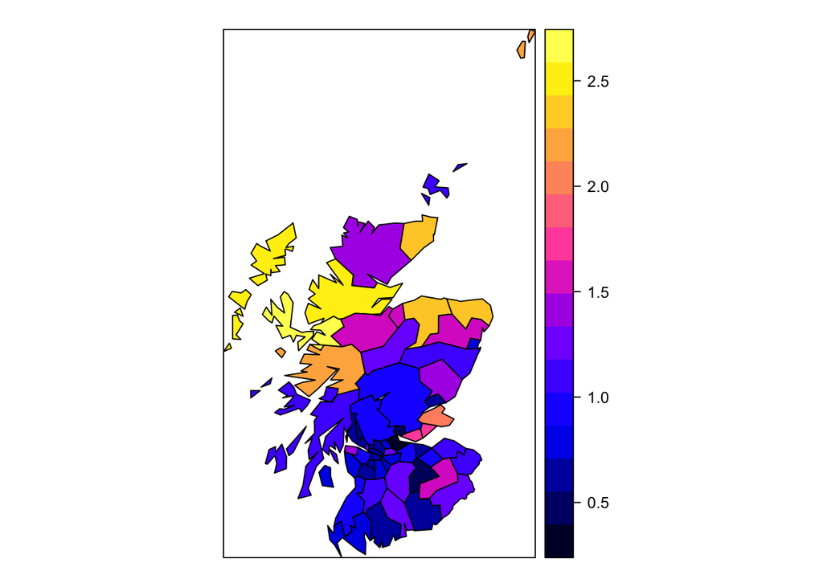

```r
# Prepare everything for the map
library(maptools)
geobugs.map = readSplus("LipCancer.map") #read a map exported from WinBUGS

# Save the posterior mean of exp(v0) in a dataframe
data.exp.v0 = data.frame(ID=names(geobugs.map), post.mean=unlist(post.mean.exp.v0))
row.names(data.exp.v0) = names(geobugs.map)
wards = SpatialPolygonsDataFrame(geobugs.map,data.exp.v0)

# Mapping!
spplot(obj=wards, zcol="post.mean",main="")
```

The following plot aims to show that, with the hierarchical model, estimated RRs are shrinked towards the mean (less variability than SMRs). We compare the $SMR_i=y_i/E_i$ with the estimated RRs.

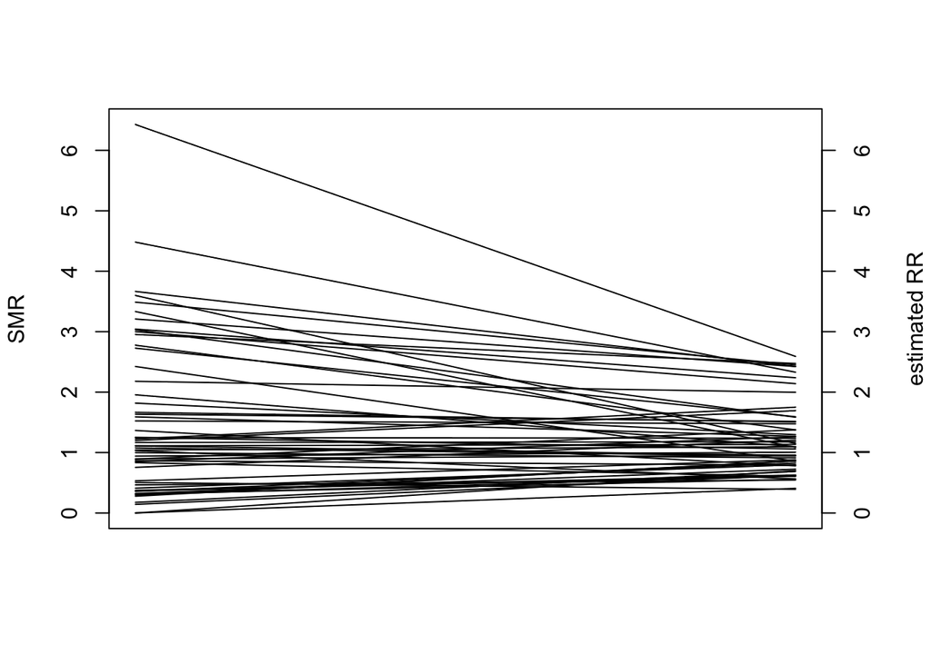

```r
SMR_estRR=cbind(LipCancerData$O/LipCancerData$E, unlist(post.mean.exp.v0))

op = par(mar = c(5,4,4,4) + 0.1)
plot(SMR_estRR[,1],type="n",ylab="SMR",xaxt="n",xlab="")
for(i in 1:56)  segments(1,SMR_estRR[i,1],56,SMR_estRR[i,2])
axis(side = 4)
mtext("estimated RR", side = 4, line = 3, cex = par("cex.lab"))
```

## 3. Compute the map of excess risk

We are interested in mapping the excess risk defined as $p(\exp(v_{0i})>1\mid y)$ or equivalently as $p(v_{0i}>0\mid y)$. We will use **`inla.pmarginal(...)`** function inside `lapply`:

```r
threshold = 0
post.prob.excess = lapply(lipcancer.poisson2$marginals.random[["id"]],
                          function(x) 1-inla.pmarginal(threshold,x))
range(unlist(post.prob.excess))
```

```
## [1] 0.0001082202 0.9999476176
```

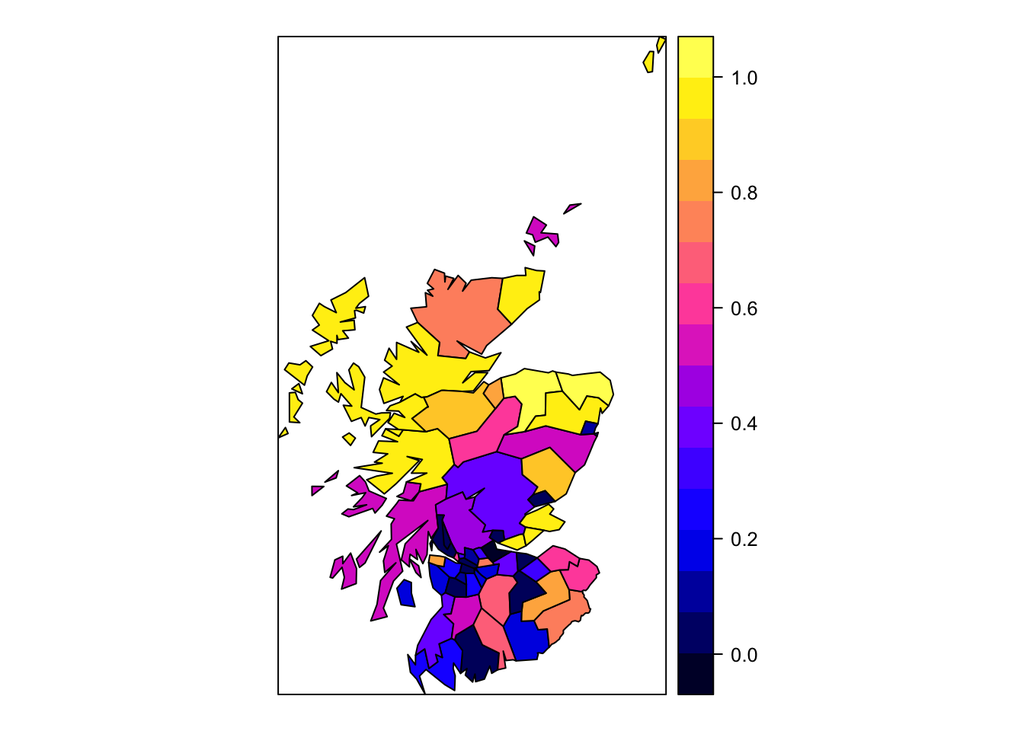

```r
# Save the posterior excess probability in a dataframe
data.prob.excess = data.frame(ID=names(geobugs.map), post.prob=unlist(post.prob.excess))
row.names(data.prob.excess) = names(geobugs.map)
wards = SpatialPolygonsDataFrame(geobugs.map,data.prob.excess)

# Mapping!
spplot(obj=wards, zcol="post.prob",main="")
```

## 3. Compute the quantile ratios through simulation

We use the **`inla.posterior.sample`** to generate samples from an approximated (joint) posterior of a fitted model. To be run it requires the option `control.compute = list(config=TRUE)` to be included in the `inla(...)` function run.

In this case we simulate 50 samples from the joint posterior:

```r
n.sim = 50
joint.post = inla.posterior.sample(n.sim,lipcancer.poisson2)
class(joint.post)
```

```
## [1] "list"
```

```r
length(joint.post)
```

```
## [1] 50
```

```r
# Let's just explore the first sample
names(joint.post[[1]])
```

```
## [1] "hyperpar" "latent"   "logdens"
```

```r
head(joint.post[[1]]) #note in "latent" you have the linear predictor AND v_0 AND beta_0 AND beta_1
```

```
## $hyperpar
## Precision for id
##         2.396706
##
## $latent
##                   sample1
## Predictor:1    2.44026037
## Predictor:2    3.73494653
## Predictor:3    1.92863128
## Predictor:4    2.84553988
## Predictor:5    2.40855879
## Predictor:6    1.73563359
## Predictor:7    3.07103860
## Predictor:8    1.77932585
## Predictor:9    1.97552517
## Predictor:10   3.09460842
## Predictor:11   2.24008229
## Predictor:12   1.61287282
## Predictor:13   1.35093024
## Predictor:14   2.17110081
## Predictor:15   2.83615215
## Predictor:16   2.01879391
## Predictor:17  -0.42202195
## Predictor:18   2.12451023
## Predictor:19   2.41645606
## Predictor:20   1.82609364
## Predictor:21   2.64390860
## Predictor:22   3.76616018
## Predictor:23   2.12680791
## Predictor:24   1.53801737
## Predictor:25   2.67464472
## Predictor:26   2.64421696
## Predictor:27   1.95368125
## Predictor:28   1.97380271
## Predictor:29   2.49595952
## Predictor:30   2.62793443
## Predictor:31   1.61133616
## Predictor:32   1.99837014
## Predictor:33   1.75546102
## Predictor:34   1.80208614
```

[output cut: 75 more lines]

```
## id:54         -1.17832629
## id:55         -0.37249869
## id:56         -0.74199189
## (Intercept):1 -0.69828307
## X:1            0.09403659
##
## $logdens
## $logdens$hyperpar
## [1] -0.8194613
##
## $logdens$latent
## [1] 239.8139
##
## $logdens$joint
## [1] 238.9944
```

```r
length(joint.post[[1]]$latent)
```

```
## [1] 114
```

For each sample (50 in total) we compute the 5th and 95th quantiles (across areas) of log relative risks ($v_0$):

```r
n.areas = nrow(LipCancerData)

# Just select the from ...$latent the values of the random effect v_0 and save them in a matrix
joint.v = matrix(NA,n.areas,n.sim)
for(i in 1:n.sim){
        joint.v[,i] = joint.post[[i]]$latent[(n.areas+1):(n.areas*2)]
}
```

Compute column by column (for each simulation) the 5% and 95% quantile and then compute their ratio and exponentiate:

```r
v5perc = apply(joint.v,2, quantile, 0.05)
v95perc = apply(joint.v,2, quantile, 0.95)
QR90 = mean(exp(v95perc-v5perc))
QR90
```

```
## [1] 6.319925
```

## 3. Compute linear combinations $\beta_{0i}=b_0+v_{0i}$

Assume we are interested in obtaining the marginal posterior distribution for $\beta_{0i}=b_0 + v_{0i}$. To obtain it we have to define the two effects through the **`inla.make.lincombs`** command (see Martins et al., 2013). Then in the `inla(...)` function the linear combination will be included through the `lincomb` option.

We have to:

- for the intercept: define a vector of ones with the length given by the number of areas
- for the random effects: define a matrix with ones on the diagonal with `id=diag(n.areas)`

```r
lcs = inla.make.lincombs("(Intercept)" = rep(1,n.areas),
                         id = diag(n.areas))

# Check how the lincombs look like
head(names(lcs))
```

```
## [1] "lc01" "lc02" "lc03" "lc04" "lc05" "lc06"
```

```r
lcs$lc01
```

```
## [[1]]
## [[1]]$`(Intercept)`
## [[1]]$`(Intercept)`$weight
## [1] 1
##
##
##
## [[2]]
## [[2]]$id
## [[2]]$id$idx
## [1] 1
##
## [[2]]$id$weight
## [1] 1
```

```r
# Run inla including the lincombs
lipcancer.poisson3 = inla(formula,family="poisson",
                            data=LipCancerData, offset=log(E),
                            control.compute=list(config = TRUE),
                            lincomb=lcs)

head(lipcancer.poisson3$summary.lincomb.derived)
```

```
##      ID       mean        sd 0.025quant   0.5quant 0.975quant       mode kld
## lc01  1  0.4023658 0.3866990 -0.3467499  0.3988379  1.1710542  0.3916643   0
## lc02  2  0.3347820 0.2691871 -0.1917556  0.3336936  0.8667165  0.3315113   0
## lc03  3  0.3492054 0.3290957 -0.2920257  0.3475150  0.9992725  0.3440982   0
## lc04  4 -0.4076849 0.4074906 -1.2108765 -0.4075216  0.3936207 -0.4071911   0
## lc05  5  0.3705929 0.2919737 -0.1989584  0.3692988  0.9468447  0.3667077   0
## lc06  6 -0.4663620 0.4127986 -1.2811659 -0.4658025  0.3443885 -0.4646725   0
```

```r
length(lipcancer.poisson3$marginals.lincomb.derived)
```

```
## [1] 56
```

## 3. Random slope model

We want know to change the model to include also a **random slope**:
$$O_i\sim \mbox{Poisson}(\lambda_i=\rho_i E_i)$$
$$\log(\rho_i)=b_0 + v_{0i} + (b_1+v_{1i}) x_i$$
Exchangeable **priors** are specified on the random effects: $v_{0i}\sim N(0, 1/\tau_{v0})$ and $v_{1i}\sim N(0, 1/\tau_{v1})$, with $\tau_{v0}$ and $\tau_{v1}$ as hyperparameters. We assume a logGamma(1,0.00001) prior for the log precision.

```r
# Create a new index variable for the new random effect v1
LipCancerData$id2 = LipCancerData$id

formula = O ~ 1 + X +
        f(id, model="iid",hyper=list(prec=
                               list(prior="loggamma",param=c(1,0.00001)))) +
        f(id2, X, model="iid",hyper=list(prec=
                               list(prior="loggamma",param=c(1,0.00001)))) #covariate X in second position (as weight)

# Define lincombs for beta0i = b0+ v0i
lcs1 = inla.make.lincombs("(Intercept)" = rep(1,n.areas), id = diag(n.areas))
# Define lincombs for beta1i = b1 + v1i
lcs2 = inla.make.lincombs(id = diag(n.areas), X = rep(1,n.areas)) #X is the name for b1

# Check the names
names(lcs1)[1]
```

```
## [1] "lc01"
```

```r
names(lcs2)[1]
```

```
## [1] "lc01"
```

```r
# Note that INLA assigns the same names to each of the linear combinations,
#so we need to change these to avoid errors when running INLA
names(lcs2) = paste(names(lcs1),"X",sep="")

# Combine all toghether the lincombs
all.lcs = c(lcs1,lcs2)

# Run inla
lipcancer.poisson4 = inla(formula,family="poisson",
                            data=LipCancerData, offset=log(E),
                            control.compute=list(config = TRUE,
                                                 dic=TRUE),
                            lincomb=all.lcs)
summary(lipcancer.poisson4)
```

```
##
## Call:
##    c("inla(formula = formula, family = \"poisson\", data = LipCancerData, ", " offset =
##    log(E), lincomb = all.lcs, control.compute = list(config = TRUE, ", " dic = TRUE))")
## Time used:
##     Pre = 2.06, Running = 0.721, Post = 0.235, Total = 3.02
## Fixed effects:
##               mean    sd 0.025quant 0.5quant 0.975quant   mode kld
## (Intercept) -0.498 0.155     -0.807   -0.496     -0.195 -0.494   0
## X            0.070 0.015      0.042    0.070      0.099  0.069   0
##
## Linear combinations (derived):
##        ID   mean    sd 0.025quant 0.5quant 0.975quant   mode kld
## lc01    1  0.301 0.434     -0.590    0.312      1.128  0.329   0
## lc02    2  0.235 0.349     -0.571    0.262      0.849  0.292   0
## lc03    3  0.285 0.359     -0.444    0.292      0.973  0.302   0
## lc04    4 -0.439 0.423     -1.277   -0.437      0.390 -0.434   0
## lc05    5  0.306 0.329     -0.382    0.316      0.925  0.331   0
## lc06    6 -0.489 0.426     -1.332   -0.488      0.345 -0.485   0
## lc07    7  0.309 0.289     -0.326    0.324      0.833  0.342   0
## lc08    8  0.203 0.390     -0.558    0.201      0.971  0.199   0
## lc09    9  0.152 0.407     -0.639    0.149      0.959  0.143   0
## lc10   10 -0.119 0.341     -0.827   -0.110      0.526 -0.096   0
## lc11   11  0.328 0.316     -0.309    0.332      0.937  0.339   0
## lc12   12 -0.281 0.424     -1.113   -0.282      0.553 -0.283   0
## lc13   13 -0.161 0.470     -1.069   -0.167      0.780 -0.179   0
## lc14   14 -0.690 0.422     -1.526   -0.688      0.137 -0.684   0
## lc15   15  0.134 0.277     -0.426    0.138      0.666  0.145   0
## lc16   16 -0.467 0.367     -1.196   -0.466      0.250 -0.462   0
## lc17   17 -0.360 0.482     -1.301   -0.363      0.598 -0.370   0
## lc18   18 -0.163 0.356     -0.860   -0.164      0.537 -0.166   0
## lc19   19 -0.149 0.328     -0.794   -0.148      0.494 -0.148   0
## lc20   20 -0.330 0.359     -1.037   -0.330      0.374 -0.329   0
## lc21   21 -0.157 0.270     -0.696   -0.154      0.368 -0.150   0
## lc22   22 -0.751 0.305     -1.349   -0.752     -0.146 -0.753   0
## lc23   23 -0.485 0.311     -1.102   -0.483      0.124 -0.480   0
## lc24   24 -0.348 0.343     -1.022   -0.348      0.326 -0.349   0
## lc25   25  0.028 0.225     -0.412    0.028      0.469  0.028   0
## lc26   26 -0.011 0.249     -0.499   -0.011      0.479 -0.012   0
## lc27   27 -0.393 0.341     -1.062   -0.393      0.276 -0.393   0
```

[output cut: 91 more lines]

```
## Model hyperparameters:
##                       mean       sd 0.025quant 0.5quant 0.975quant     mode
## Precision for id      3.11 9.08e-01       1.70     2.98   5.23e+00     2.75
## Precision for id2 98292.48 1.02e+05    6425.01 67643.45   3.70e+05 17378.38
##
## Expected number of effective parameters(stdev): 38.93(2.88)
## Number of equivalent replicates : 1.44
##
## Deviance Information Criterion (DIC) ...............: 310.51
## Deviance Information Criterion (DIC, saturated) ....: 102.53
## Effective number of parameters .....................: 39.05
##
## Marginal log-Likelihood:  -192.09
## Posterior marginals for the linear predictor and
##  the fitted values are computed
```

```r
# Compute exponentiated posterior means
post.mean.exp.beta0 = lapply(lipcancer.poisson4$marginals.lincomb.derived[1:n.areas],
                             function(x) inla.emarginal(exp,x))
post.mean.exp.beta1 = lapply(lipcancer.poisson4$marginals.lincomb.derived[(n.areas+1):(n.areas*2)],
                             function(x) inla.emarginal(exp,x))

# Combine everything in a dataframe
data.lcs.beta0_beta1 = data.frame(ID=names(geobugs.map), post.mean.exp.beta0=unlist(post.mean.exp.beta0),
                                  post.mean.exp.beta1=unlist(post.mean.exp.beta1))
row.names(data.lcs.beta0_beta1) = names(geobugs.map)


wards = SpatialPolygonsDataFrame(geobugs.map,data.lcs.beta0_beta1)
names(wards)
```

```
## [1] "ID"                  "post.mean.exp.beta0" "post.mean.exp.beta1"
```

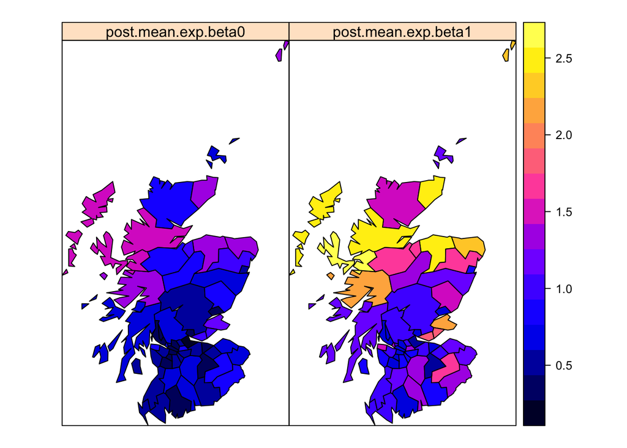

```r
spplot(obj=wards, zcol=c("post.mean.exp.beta0","post.mean.exp.beta1"),main="")
```

## 3. Model comparison using DIC

Let’s compare the two models (one with random intercepts and the other with random slopes). To get DIC the option `control.compute=list(dic=TRUE)` has to be specified.

```r
names(lipcancer.poisson4$dic)
```

```
##  [1] "dic"               "p.eff"             "mean.deviance"     "deviance.mean"
##  [5] "dic.sat"           "mean.deviance.sat" "deviance.mean.sat" "family.dic"
##  [9] "family.dic.sat"    "family.p.eff"      "family"            "local.dic"
## [13] "local.dic.sat"     "local.p.eff"
```

```r
lipcancer.poisson4$dic$dic #model with random slopes
```

```
## [1] 310.5109
```

```r
lipcancer.poisson2$dic$dic #model with random intercepts
```

```
## [1] 310.7653
```

It is possible to obtain other cross-validated predictive measures such as

- conditional predictive ordinate (cpo): $p(y_i\mid y_{-i})$
- probability integral transformation (pit): $p(y_i^\mbox{new} \leq y_i\mid y_{-i})$

with the option `control.compute=list(cpo=TRUE)`.